# Análisis predictivo y exploratorio de abandono en secundaria

IESTA, Universidad de la República

## Estructura

- Motivación y objetivos
- Exploración de los datos
- Modelos predictivos, bosques aleatorios con datos desbalanceados
- Comentarios finales

## Motivación

Educación formal en Uruguay:

- Educación preprimaria e inicial (entre 3 y 5 años)
- Educación primaria (entre 6 y 11 años)
- Educación secundaria (entre 12 y 17 años)
- Educación terciaria o superior (18 años o más)

## Motivación

Si bien se ha logrado tener un nivel importante de universalización de la educación primaria, se encuentran serios problemas en la educación secundaria para lograr retener a los estudiantes en el sistema.

## Objetivo

El primer año de secundaria es el que presenta mayores niveles de abandono.

- Analizar la población en riesgo de abandono es fundamental para entender el problema y obtener información relevante para el desarrollo de políticas públicas.
- Explorar y predecir el abandono de los alumnos pertenecientes a primer año de educación secundaria pública en Uruguay.

## Población

- Población: estudiantes de primero de educación secundaria que cursan primero en el año 2016.
- Dicha población se compone de una matrícula de 40.233 alumnos, que pertenecen a 254 centros educativos.
- Se dispone de las transiciones de dichos alumnos entre los años 2016 y 2017.

## Abandono

- Abandono: si cursó primero de CES en 2016 y en 2017 no se anotó en el sistema de educación pública.
- Limitante no hay datos de educación privada.
- Usando esta definición hay 7% de abandono en 2016-2017

## Abandono 1ero 2016-2017

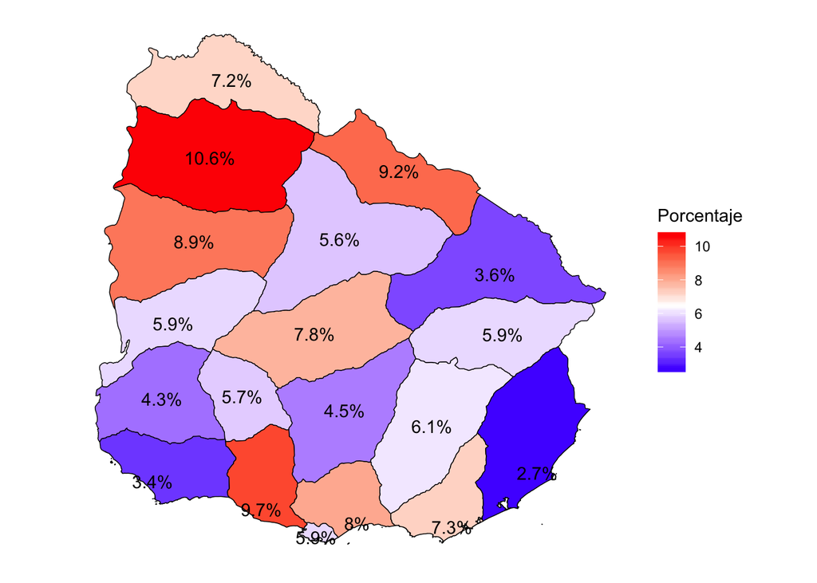

## Abandono 1ero 2016-2017

- La distribución de los alumnos que no abandonan es similar para mujeres y hombres (50.45% mujeres y 49.55 % hombres).
- Para los que abandonan, hay un porcentaje mayor de alumnos de sexo masculino (57 %) que femeninos (43 %).
- ¿Existen diferencias en la distribución del abandono según género a nivel departamental?

## Abandono por departamento y género

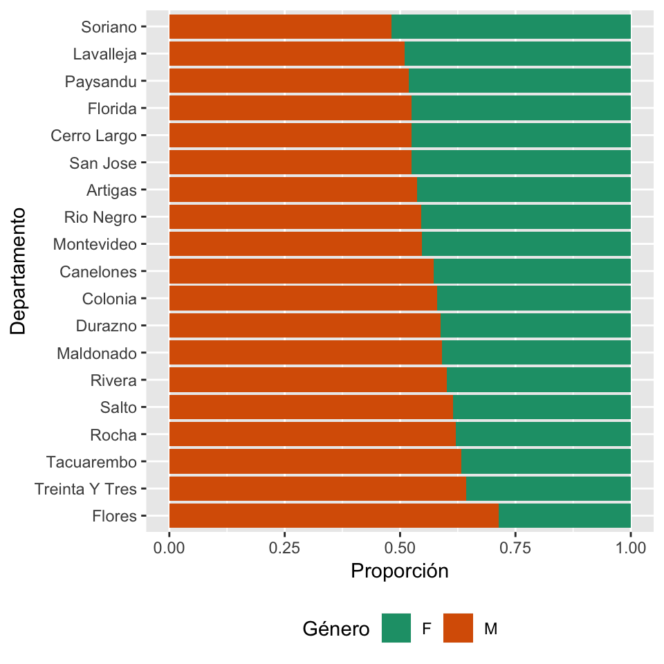

## Contextos socioculturales y abandono

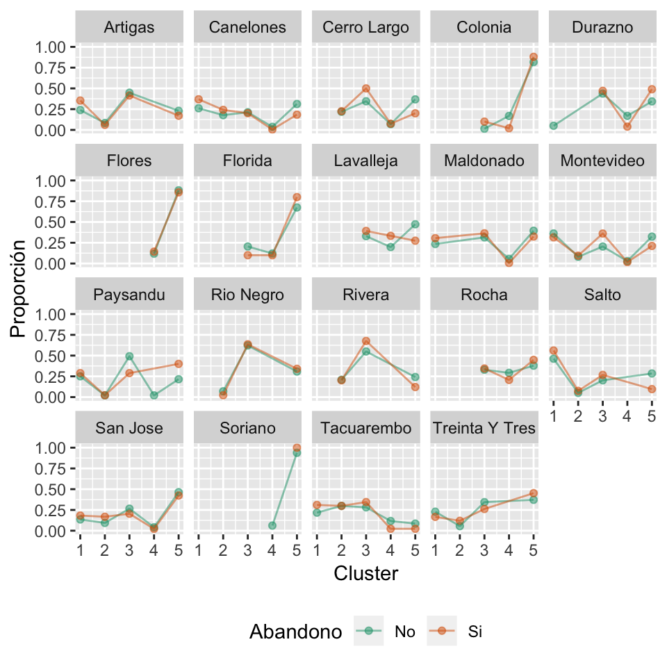

## Modelos predictivos

Modelos de clasificación para el abandono

- Variable de respuesta categórica con dos niveles (abandona, no abandona).
- Variables explicativas: Contexto sociocultural, sexo, extra edad fuerte, extra edad leve, inasistencias relativas, centro educativo, departamento.
- Problema: los datos están muy desbalanceados sólo un 7% abandonan
- Distintas estrategias usando bosques aleatorios (RF)

## Bosque aleatorio, RF

Bosque aleatorio es un método de agregación supervisado basado en combinar modelos individuales de tipo árbol. Dos fuentes de aleatoriedad son introducidas, agregación bootstrap y selección aleatoria de variables en la partición del nodo.

## Diagrama bosque aleatorio clásico

[figure not shown]

## Datos desbalanceados

- Los algoritmos de ML no tienen mucha información de la clase minoritaria para tener buenas predicciones en la clase minoritaria.
- Los algoritmos son guiados por la precisión, minimizan el error global donde la clase minoritaria tiene poco peso.
- Los algoritmos de ML asumen que las clases están balanceadas.
- También asumen que los errores obtenidos de diferentes clases tienen el mimo costo.

## Random Forest, clásico

```
##
## Call:
##  randomForest(formula = Abandono ~ nro_doc_centro_educ + inas_rel +      cl2 + Sexo + EE_Fuerte, data = dat2)
##                Type of random forest: classification
##                      Number of trees: 500
## No. of variables tried at each split: 2
##
##         OOB estimate of  error rate: 5.69%
## Confusion matrix:
##       0   1 class.error
## 0 26503  63 0.002371452
## 1  1543 123 0.926170468
```

## Random Forest, datos desbalanceados

- Podemos incorporar pesos a las clases y penalizar el error de clasificación en la clase minoritaria (WRF)
- Combinar técnicas de muestreo y métodos de agregación. Sub muestrea la clase mayoritaria y crece los árboles con muestras más balanceadas (BRF).

## Random Forest ponderado, WRF

- Aprendizaje sensible al costo
- Debemos incorporar mayor penalidad al error de clasificación en la clase minoritaria.
- En WRF los pesos se traducen en dos lugares: usa pesos para encontrar las particiones de cada árbol. En los nodos terminales de cada árbol se ponderan las clases y se usa voto mayoritario ponderado.

## Random Forest ponderado (WRF)

```
##
## Call:
##  randomForest(formula = Abandono ~ nro_doc_centro_educ + inas_rel +      cl2 + Sexo + EE_Fuerte, data = dat2, classwt = c(1, 5))
##                Type of random forest: classification
##                      Number of trees: 500
## No. of variables tried at each split: 2
##
##         OOB estimate of  error rate: 38.33%
## Confusion matrix:
##       0     1 class.error
## 0 15909 10657  0.40115185
## 1   163  1503  0.09783914
```

## Random Forest, balanceado (BRF)

- Saco muestras bootstrap para la clase minoritaria y aleatoriamente con reposición, selecciono el mismo número de casos para la clase mayoritaria.
- Ajusto CART para cada muestra bootstrap y selecciono aleatoriamente un subconjunto de variables para la partición de cada nodo
- Basado en voto mayoritario obtengo la predicción del bosque

## Random Forest, balanceado (BRF)

```
##
## Call:
##  randomForest(formula = Abandono ~ nro_doc_centro_educ + inas_rel +      cl2 + Sexo + EE_Fuerte, data = dat2, strata = dat2$Abandono,      sampsize = rep(1666, 2))
##                Type of random forest: classification
##                      Number of trees: 500
## No. of variables tried at each split: 2
##
##         OOB estimate of  error rate: 17.76%
## Confusion matrix:
##       0    1 class.error
## 0 21893 4673   0.1759015
## 1   340 1326   0.2040816
```

## Random Forest, ROC

- Comparar la performance, uso ROC (Receiver operating characteristic curve )
- ROC es una representación gráfica que muestra el trade off entre los TPR y FPR para todos los puntos de corte

## Random Forest, ROC

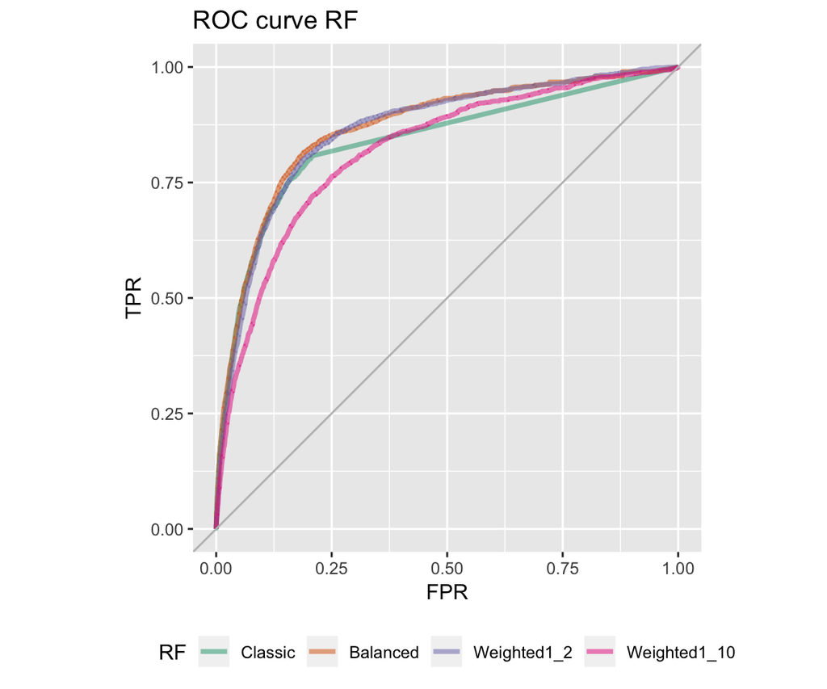

## Comentarios Finales

Datos desbalanceados:

- Importante usar modelos que tomen en cuenta esta característica
- Seleccionar medidas de performance apropiadas para evaluar los modelos
- Seleccionar modelos en base a nuestro interés en el problema particular
- En nuestro caso reducir los Falsos negativos (que abandone y clasificarlo erróneamente)

## Información e Invitación

1. Slides: https://github.com/natydasilva/riocuarto
2. email: natalia@iesta.edu.uy, twitter:@pacocuak, webpage: http://natydasilva.com
3. LatinR: Conferencia sobre el uso y desarrollo de R, 3 al 5 de Setiembre en Buenos Aires
4. Web: https://latinr.github.io, twitter: @LatinR2018
5. Querés saber qué es R-Ladies, preguntame